# Chloropleths

Ayoush Mukherjee, Charlene Quach

February 16, 2018

Check this github link for the repository to get all code and data: https://github.com/AyoushM/ggplot-visualization-tutorial

## Reading the Dataset

```r
KC_Prelim <- read.csv('Datasets/kc_house_data.csv')
```

### Looking at the variables

```r
colnames(KC_Prelim)
```

```
##  [1] "id"            "date"          "price"         "bedrooms"
##  [5] "bathrooms"     "sqft_living"   "sqft_lot"      "floors"
##  [9] "waterfront"    "view"          "condition"     "grade"
## [13] "sqft_above"    "sqft_basement" "yr_built"      "yr_renovated"
## [17] "zipcode"       "lat"           "long"          "sqft_living15"
## [21] "sqft_lot15"
```

### Looking at the summary statistics for each of the features

```r
summary(KC_Prelim)
```

```
##        id                         date           price
##  Min.   :1.000e+06   20140623T000000:  142   Min.   :  75000
##  1st Qu.:2.123e+09   20140625T000000:  131   1st Qu.: 321950
##  Median :3.905e+09   20140626T000000:  131   Median : 450000
##  Mean   :4.580e+09   20140708T000000:  127   Mean   : 540088
##  3rd Qu.:7.309e+09   20150427T000000:  126   3rd Qu.: 645000
##  Max.   :9.900e+09   20150325T000000:  123   Max.   :7700000
##                      (Other)        :20833
##     bedrooms        bathrooms      sqft_living       sqft_lot
##  Min.   : 0.000   Min.   :0.000   Min.   :  290   Min.   :    520
##  1st Qu.: 3.000   1st Qu.:1.750   1st Qu.: 1427   1st Qu.:   5040
##  Median : 3.000   Median :2.250   Median : 1910   Median :   7618
##  Mean   : 3.371   Mean   :2.115   Mean   : 2080   Mean   :  15107
##  3rd Qu.: 4.000   3rd Qu.:2.500   3rd Qu.: 2550   3rd Qu.:  10688
##  Max.   :33.000   Max.   :8.000   Max.   :13540   Max.   :1651359
##
##      floors        waterfront            view          condition
##  Min.   :1.000   Min.   :0.000000   Min.   :0.0000   Min.   :1.000
##  1st Qu.:1.000   1st Qu.:0.000000   1st Qu.:0.0000   1st Qu.:3.000
##  Median :1.500   Median :0.000000   Median :0.0000   Median :3.000
##  Mean   :1.494   Mean   :0.007542   Mean   :0.2343   Mean   :3.409
##  3rd Qu.:2.000   3rd Qu.:0.000000   3rd Qu.:0.0000   3rd Qu.:4.000
##  Max.   :3.500   Max.   :1.000000   Max.   :4.0000   Max.   :5.000
##
##      grade          sqft_above   sqft_basement       yr_built
##  Min.   : 1.000   Min.   : 290   Min.   :   0.0   Min.   :1900
##  1st Qu.: 7.000   1st Qu.:1190   1st Qu.:   0.0   1st Qu.:1951
##  Median : 7.000   Median :1560   Median :   0.0   Median :1975
##  Mean   : 7.657   Mean   :1788   Mean   : 291.5   Mean   :1971
##  3rd Qu.: 8.000   3rd Qu.:2210   3rd Qu.: 560.0   3rd Qu.:1997
##  Max.   :13.000   Max.   :9410   Max.   :4820.0   Max.   :2015
##
##   yr_renovated       zipcode           lat             long
##  Min.   :   0.0   Min.   :98001   Min.   :47.16   Min.   :-122.5
##  1st Qu.:   0.0   1st Qu.:98033   1st Qu.:47.47   1st Qu.:-122.3
##  Median :   0.0   Median :98065   Median :47.57   Median :-122.2
##  Mean   :  84.4   Mean   :98078   Mean   :47.56   Mean   :-122.2
##  3rd Qu.:   0.0   3rd Qu.:98118   3rd Qu.:47.68   3rd Qu.:-122.1
##  Max.   :2015.0   Max.   :98199   Max.   :47.78   Max.   :-121.3
##
##  sqft_living15    sqft_lot15
##  Min.   : 399   Min.   :   651
##  1st Qu.:1490   1st Qu.:  5100
##  Median :1840   Median :  7620
##  Mean   :1987   Mean   : 12768
##  3rd Qu.:2360   3rd Qu.: 10083
##  Max.   :6210   Max.   :871200
##
```

### Cleaning the dataset to use for analysis

Items to alter: We do not need the id. The date needs to be converted into the datetime format for meaningful use. Sqft_living and sqft_lot can be removed as we have updated figures in sqft_living15 and sqft_lot15 Waterfront is a categorical variable. View is the number of times it has been viewed which can be removed for this analysis. Condition is ordinal. Zipcode is categorical.

```r
# Creating Clean Dataset
KingCounty <- KC_Prelim[-c(1,6,7, 10)]

# Cleaning Dates
KingCounty$date <- as.Date(KingCounty$date, '%y%y%m%d')

# Fixing categorical variables
KingCounty$waterfront <- as.character(KingCounty$waterfront)
KingCounty$waterfront[KingCounty$waterfront == '0'] <- 'No'
KingCounty$waterfront[KingCounty$waterfront != 'No'] <- 'Yes'
KingCounty$waterfront <- as.factor(KingCounty$waterfront)

KingCounty$condition <- as.ordered(KingCounty$condition)
KingCounty$zipcode <- as.factor(KingCounty$zipcode)
```

### Checking updated summary statistics

```r
summary(KingCounty)
```

```
##       date                price            bedrooms        bathrooms
##  Min.   :2014-05-02   Min.   :  75000   Min.   : 0.000   Min.   :0.000
##  1st Qu.:2014-07-22   1st Qu.: 321950   1st Qu.: 3.000   1st Qu.:1.750
##  Median :2014-10-16   Median : 450000   Median : 3.000   Median :2.250
##  Mean   :2014-10-29   Mean   : 540088   Mean   : 3.371   Mean   :2.115
##  3rd Qu.:2015-02-17   3rd Qu.: 645000   3rd Qu.: 4.000   3rd Qu.:2.500
##  Max.   :2015-05-27   Max.   :7700000   Max.   :33.000   Max.   :8.000
##
##      floors      waterfront  condition     grade          sqft_above
##  Min.   :1.000   No :21450   1:   30   Min.   : 1.000   Min.   : 290
##  1st Qu.:1.000   Yes:  163   2:  172   1st Qu.: 7.000   1st Qu.:1190
##  Median :1.500               3:14031   Median : 7.000   Median :1560
##  Mean   :1.494               4: 5679   Mean   : 7.657   Mean   :1788
##  3rd Qu.:2.000               5: 1701   3rd Qu.: 8.000   3rd Qu.:2210
##  Max.   :3.500                         Max.   :13.000   Max.   :9410
##
##  sqft_basement       yr_built     yr_renovated       zipcode
##  Min.   :   0.0   Min.   :1900   Min.   :   0.0   98103  :  602
##  1st Qu.:   0.0   1st Qu.:1951   1st Qu.:   0.0   98038  :  590
##  Median :   0.0   Median :1975   Median :   0.0   98115  :  583
##  Mean   : 291.5   Mean   :1971   Mean   :  84.4   98052  :  574
##  3rd Qu.: 560.0   3rd Qu.:1997   3rd Qu.:   0.0   98117  :  553
##  Max.   :4820.0   Max.   :2015   Max.   :2015.0   98042  :  548
##                                                   (Other):18163
##       lat             long        sqft_living15    sqft_lot15
##  Min.   :47.16   Min.   :-122.5   Min.   : 399   Min.   :   651
##  1st Qu.:47.47   1st Qu.:-122.3   1st Qu.:1490   1st Qu.:  5100
##  Median :47.57   Median :-122.2   Median :1840   Median :  7620
##  Mean   :47.56   Mean   :-122.2   Mean   :1987   Mean   : 12768
##  3rd Qu.:47.68   3rd Qu.:-122.1   3rd Qu.:2360   3rd Qu.: 10083
##  Max.   :47.78   Max.   :-121.3   Max.   :6210   Max.   :871200
##
```

# Chloropleth

## Libraries

```r
library(ggplot2)
library(ggmap)
library(rgdal)
```

### Reading the shapefile

The shape file was sourced from King County: https://www5.kingcounty.gov/gisdataportal/

First we check the layers in the shape file. Layers are different representations of data that are in the shape file.

```r
ogrListLayers('Datasets/zipcode')
```

```
## [1] "zipcode"
## attr(,"driver")
## [1] "ESRI Shapefile"
## attr(,"nlayers")
## [1] 1
```

The shape file contains only one layer, which is that of the zipcodes. Now we read the shape file and do a preliminary plot of the of the shapefile

```r
kc_map <- readOGR('Datasets/zipcode', layer = 'zipcode')
```

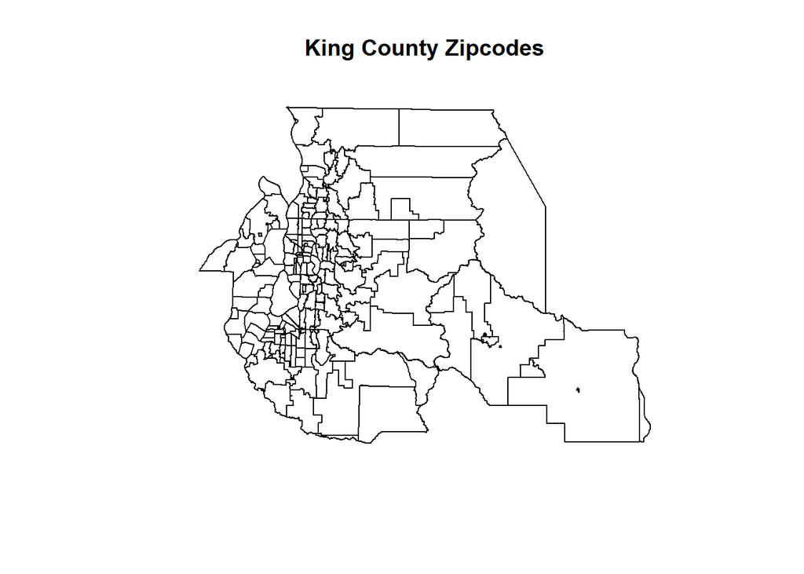

```r
plot(kc_map, main = 'King County Zipcodes')
```

The shapefile then needs to be converted into a ggplot2 object so that it can be used for plotting. The region parameter indicates what attribute of the map should be used as the ID

```r
kc_df <- fortify(kc_map, region = 'ZIPCODE')
```

## Preliminary Chloropleth Plotting

To plot this, we’re using the ‘price’ field, which is the price at which the house was sold.

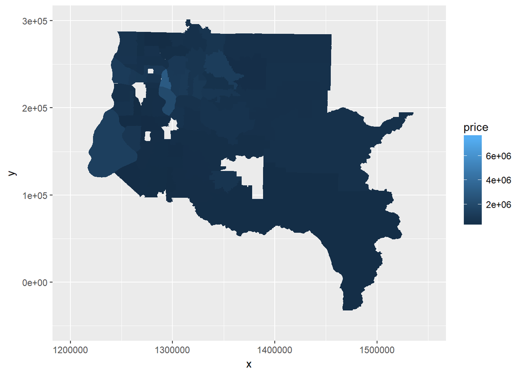

```r
ggplot() + geom_map(map = kc_df, data = KingCounty, aes(map_id = zipcode, fill = price)) + expand_limits(x = c(1200000, 1550000), y = c(-50000, 300000))
```

So, this is how a chloropleth looks. But this is all wrong. The scale is intuitively misleading. Darker colors are for lower values. Also, we don’t know what kind of normalization was used to arrive at the prices.

## Creating meaningful features for plotting

Okay, now that we know how it looks, we can make it better.

```r
library(plyr)
KingCounty$Price_PerSqft <- KingCounty$price/KingCounty$sqft_living15
kc <- ddply(KingCounty, .(zipcode), summarize, MeanPPSF = mean(Price_PerSqft))
```

Let’s plot using that data now.

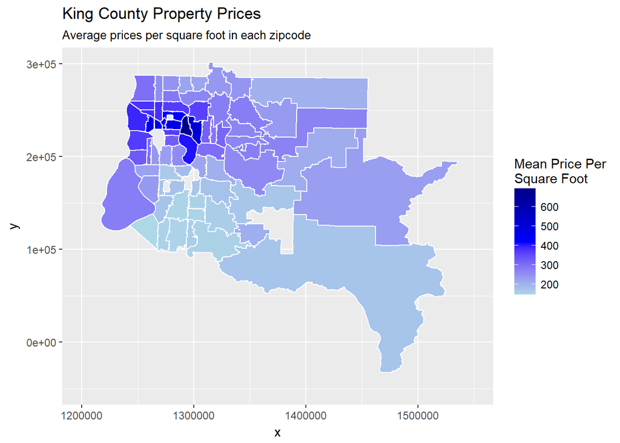

```r
ggplot() +
  geom_map(map = kc_df, data = kc, aes(map_id = zipcode, fill = MeanPPSF), color='white') +
  expand_limits(x = c(1200000, 1550000), y = c(-50000, 300000)) +
  scale_fill_gradient2(low = 'lightblue', midpoint = (min(kc$MeanPPSF) + max(kc$MeanPPSF))/2, mid = 'blue', high = 'darkblue', limits = c(min(kc$MeanPPSF), max(kc$MeanPPSF))) +
  labs(fill = 'Mean Price Per\nSquare Foot') +
  ggtitle('King County Property Prices', subtitle = 'Average prices per square foot in each zipcode')
```

But blue? Seriously? No.

Better Colors.

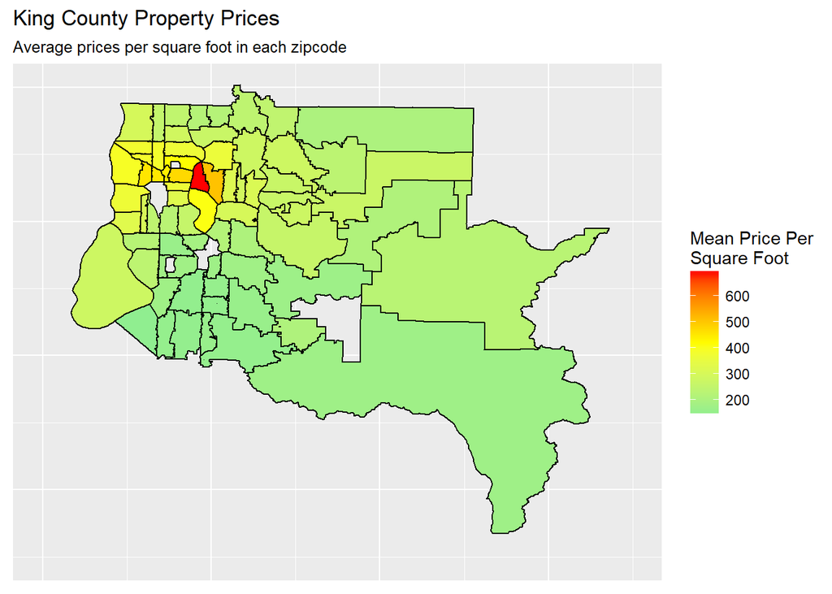

```r
ggplot() +
  geom_map(map = kc_df, data = kc, aes(map_id = zipcode, fill = MeanPPSF), color='black') +
  expand_limits(x = c(1200000, 1550000), y = c(-50000, 300000)) +
  scale_fill_gradient2(low = 'lightgreen', midpoint = (min(kc$MeanPPSF) + max(kc$MeanPPSF))/2, mid = 'yellow', high = 'red', limits = c(min(kc$MeanPPSF), max(kc$MeanPPSF))) +
  labs(fill = 'Mean Price Per\nSquare Foot') +
  ggtitle('King County Property Prices', subtitle = 'Average prices per square foot in each zipcode') +
  theme(axis.title = element_blank(), axis.text = element_blank(), axis.ticks = element_blank())
```